# Coronavirus US - USA Facts

davegoblue

10/25/2020

## Background

This is a subset of the code contained in Coronavirus_Statistics_v002.Rmd. This file includes the latest code for analyzing data from [USA Facts](https://usafacts.org/visualizations/coronavirus-covid-19-spread-map/). USA Facts maintains data on cases and deaths by county for coronavirus in the US. Downloaded data are unique by county with date as a column and a separate file for each of cases, deaths, and population..

Functions are available in Coronavirus_Statistics_Functions_USAF_v003.R and Coronavirus_Statistics_Functions_Shared_v003.R. The code leverages tidyverse and a variable mapping file throughout:

```r
# All functions assume that tidyverse and its components are loaded and available
# Other functions are declared in the sourcing files or use library::function()
library(tidyverse)
```

```r
# If the same function is in both files, use the version from the more specific source
source("./Coronavirus_Statistics_Functions_Shared_v003.R")
source("./Coronavirus_Statistics_Functions_USAF_v003.R")

# Create a variable mapping file
varMapper <- c("cases"="Cases",
               "newCases"="Increase in cases, most recent 30 days",
               "casesroll7"="Rolling 7-day mean cases",
               "deaths"="Deaths",
               "newDeaths"="Increase in deaths, most recent 30 days",
               "deathsroll7"="Rolling 7-day mean deaths",
               "cpm"="Cases per million",
               "cpm7"="Cases per day (7-day rolling mean) per million",
               "newcpm"="Increase in cases, most recent 30 days, per million",
               "dpm"="Deaths per million",
               "dpm7"="Deaths per day (7-day rolling mean) per million",
               "newdpm"="Increase in deaths, most recent 30 days, per million",
               "hpm7"="Currently Hospitalized per million (7-day rolling mean)",
               "tpm"="Tests per million",
               "tpm7"="Tests per million per day (7-day rolling mean)"
               )
```

## Running Code

The main function is readRunUSAFacts(), which performs multiple tasks:

STEP 0: Optionally, downloads the latest data files from USA Facts  
STEP 1: Reads a population file by county that has been downloaded from USA Facts to local  
STEP 2: Reads case and death data, integrates with population for per-capita, and creates an integrated file  
STEP 3: Filter data based on population and/or burden thresholds, create segments if requested, and return an integrated file  
STEP 4a: Extract the relevant clustering vector (created in step 3 or passed as an argument)  
STEP 4b: Create integrated dataset with clusters and display relevant plots STEP 5: Add back counties that fell below burden or population thresholds and assign as cluster 999  
STEP 6: Returns a list of key data frames, modeling objects, named cluster vectors, etc.

Broadly, there are two use cases for the function:

1. Download new data, create new segments, and assess the segments
2. Download new data, use existing segments, and assess the segments

An example for each use case is created, with the caveat that data are not repeatedly downloaded (process is cached) to avoid unnecessary calls to the USA Facts server.

Further, files can be saved in RDS format so they can be loaded and used later.

#### *Use Case 1: Download new data, create segments, assess performance*

The full process downloads data, creates segments, and assesses performance. Rules-based segmentation that integrated total burden and shape (percent by month) tends to work well for creating county-level clusters:

```r
# Locations for the population, case, and death file
popLoc <- "./RInputFiles/Coronavirus/covid_county_population_usafacts.csv"
caseLoc <- "./RInputFiles/Coronavirus/covid_confirmed_usafacts_downloaded_20201026.csv"
deathLoc <- "./RInputFiles/Coronavirus/covid_deaths_usafacts_downloaded_20201026.csv"

# Create 3x3 clusters for burden x shape, with focus on cases rather than deaths
cty_20201026 <- readRunUSAFacts(maxDate="2020-10-24",
                                popLoc=popLoc,
                                caseLoc=caseLoc,
                                deathLoc=deathLoc,
                                dlCaseDeath=!(file.exists(caseLoc) & file.exists(deathLoc)),
                                oldFile=readFromRDS("burden_20200903_new"),
                                existingStateClusters=readFromRDS("test_hier5_201025")$useClusters,
                                createClusters=TRUE,
                                hierarchical=NA,
                                minShape=4,
                                maxShape=9,
                                ratioDeathvsCase = 0.001,
                                ratioTotalvsShape = 0.25,
                                minDeath=100,
                                minCase=5000,
                                hmlSegs=3,
                                eslSegs=3,
                                seed=2010261358,
                                orderCluster="cpm"
                                )
```

```
## Rows: 885,015
## Columns: 6
## $ countyFIPS <dbl> 0, 0, 0, 0, 0, 0, 0, 0, 0, 0, 0, 0, 0, 0, 0, 0, 0, 0, 0,...
## $ countyName <chr> "Statewide Unallocated", "Statewide Unallocated", "State...
## $ state      <chr> "AL", "AL", "AL", "AL", "AL", "AL", "AL", "AL", "AL", "A...
## $ stateFIPS  <dbl> 1, 1, 1, 1, 1, 1, 1, 1, 1, 1, 1, 1, 1, 1, 1, 1, 1, 1, 1,...
## $ date       <date> 2020-01-22, 2020-01-23, 2020-01-24, 2020-01-25, 2020-01...
## $ cumCases   <dbl> 0, 0, 0, 0, 0, 0, 0, 0, 0, 0, 0, 0, 0, 0, 0, 0, 0, 0, 0,...
```

```
## Rows: 885,015
## Columns: 6
## $ countyFIPS <dbl> 0, 0, 0, 0, 0, 0, 0, 0, 0, 0, 0, 0, 0, 0, 0, 0, 0, 0, 0,...
## $ countyName <chr> "Statewide Unallocated", "Statewide Unallocated", "State...
## $ state      <chr> "AL", "AL", "AL", "AL", "AL", "AL", "AL", "AL", "AL", "A...
## $ stateFIPS  <dbl> 1, 1, 1, 1, 1, 1, 1, 1, 1, 1, 1, 1, 1, 1, 1, 1, 1, 1, 1,...
## $ date       <date> 2020-01-22, 2020-01-23, 2020-01-24, 2020-01-25, 2020-01...
## $ cumDeaths  <dbl> 0, 0, 0, 0, 0, 0, 0, 0, 0, 0, 0, 0, 0, 0, 0, 0, 0, 0, 0,...
```

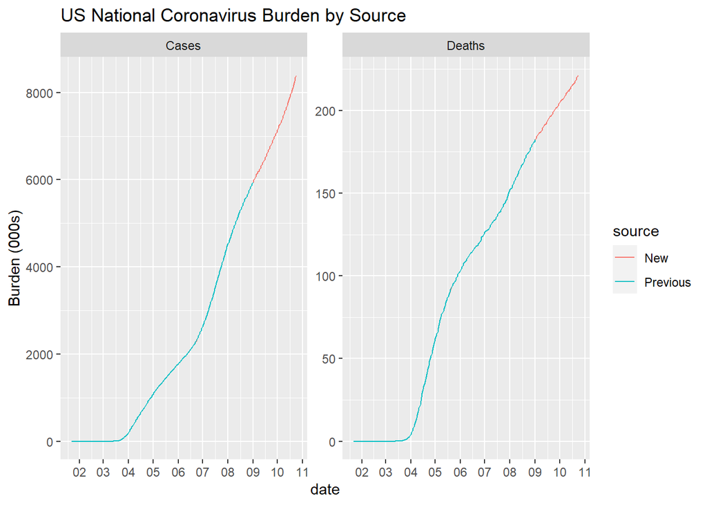

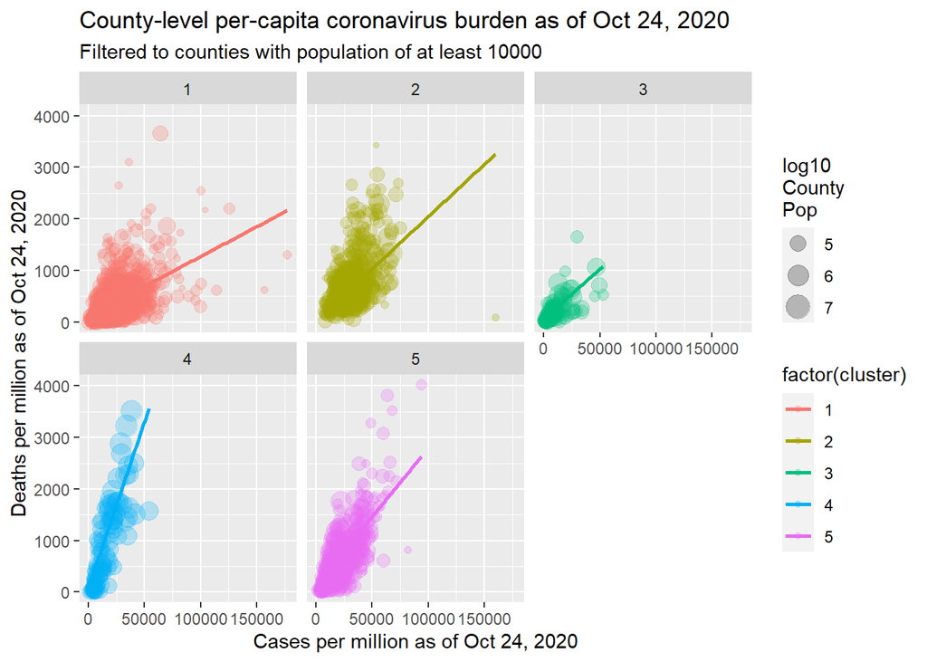

```
##
## Shape curves will impose a floor of at least 5000 cases per million
## Shape curves will impose a floor of at least 100 deaths per million
## *** Counties with 0 cases/deaths or that fall below the floor for minCase/minDeath ***
## # A tibble: 1 x 4
##   cpm_mean_is0 dpm_mean_is0 dpm_mean_ltDeath cpm_mean_ltCase
##          <dbl>        <dbl>            <dbl>           <dbl>
## 1            0       0.0138            0.118          0.0446
```

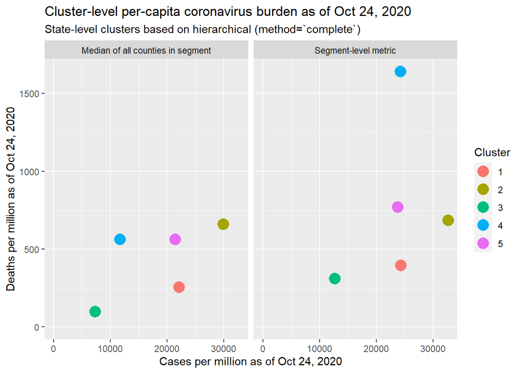

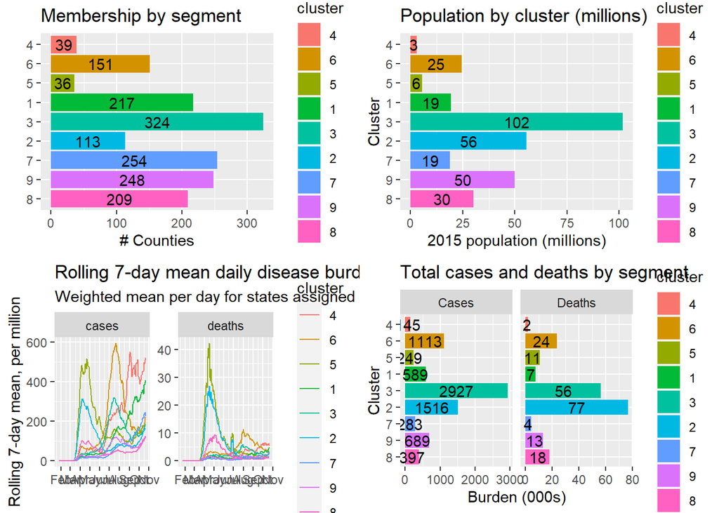

```
##
## Recency is defined as 2020-09-25 through current
##
## Recency is defined as 2020-09-25 through current
```

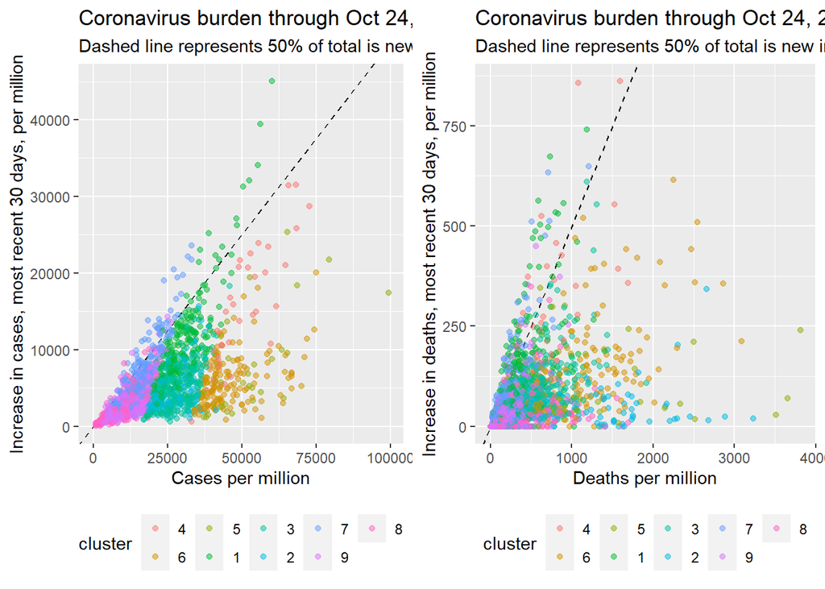

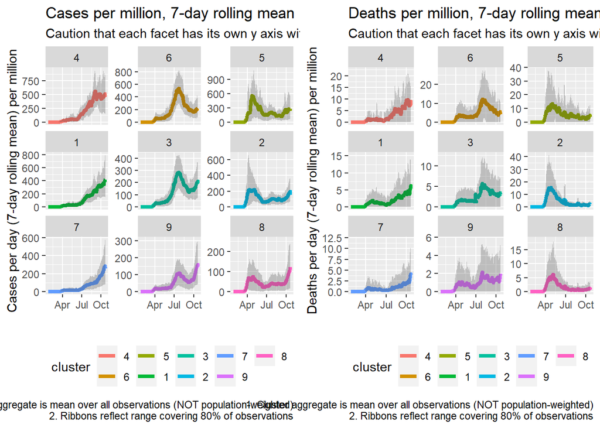

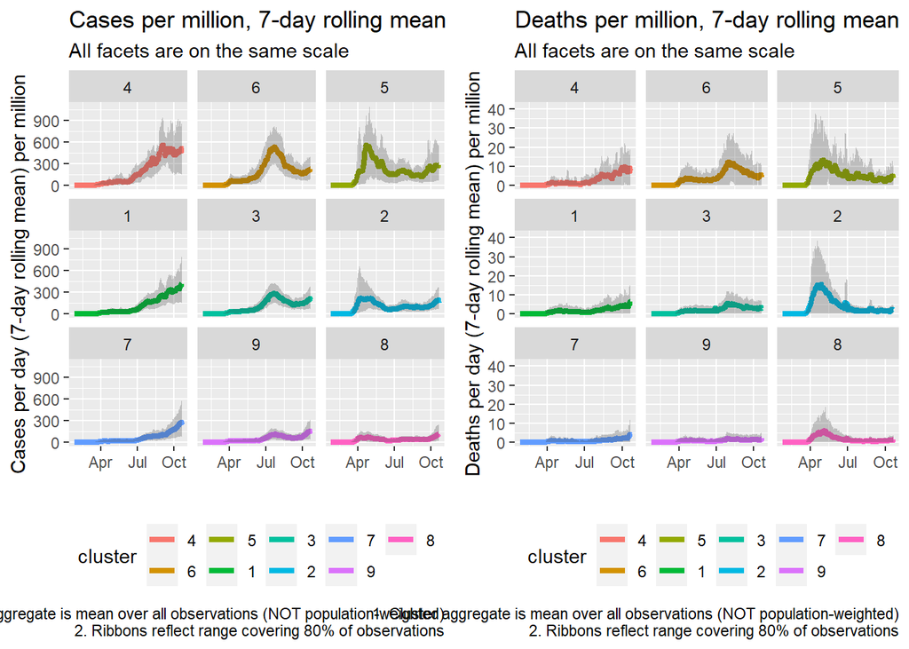

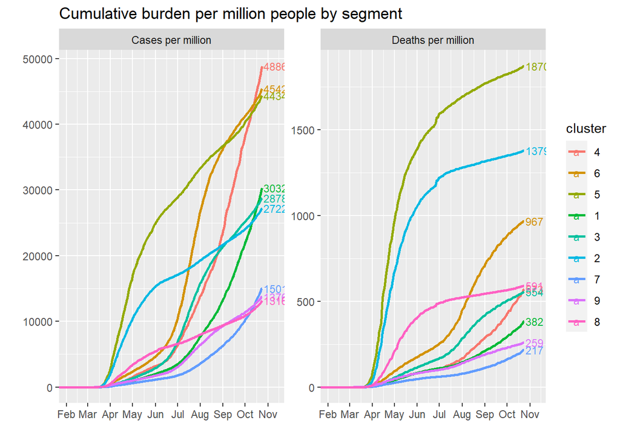

#### *Use Case 2: Download new data, apply existing segments, assess performance*

```r
# Locations for the population, case, and death file
popLoc <- "./RInputFiles/Coronavirus/covid_county_population_usafacts.csv"
caseLoc <- "./RInputFiles/Coronavirus/covid_confirmed_usafacts_downloaded_20201026.csv"
deathLoc <- "./RInputFiles/Coronavirus/covid_deaths_usafacts_downloaded_20201026.csv"

# Run old segments against new data
cty_old_20201026 <- readRunUSAFacts(maxDate="2020-10-24",
                                    popLoc=popLoc,
                                    caseLoc=caseLoc,
                                    deathLoc=deathLoc,
                                    dlCaseDeath=!(file.exists(caseLoc) & file.exists(deathLoc)),
                                    oldFile=readFromRDS("burden_20200903_new"),
                                    existingCountyClusters=readFromRDS("clustVec_county_20200903_new")
                                    )
```

```
## Rows: 885,015
## Columns: 6
## $ countyFIPS <dbl> 0, 0, 0, 0, 0, 0, 0, 0, 0, 0, 0, 0, 0, 0, 0, 0, 0, 0, 0,...
## $ countyName <chr> "Statewide Unallocated", "Statewide Unallocated", "State...
## $ state      <chr> "AL", "AL", "AL", "AL", "AL", "AL", "AL", "AL", "AL", "A...
## $ stateFIPS  <dbl> 1, 1, 1, 1, 1, 1, 1, 1, 1, 1, 1, 1, 1, 1, 1, 1, 1, 1, 1,...
## $ date       <date> 2020-01-22, 2020-01-23, 2020-01-24, 2020-01-25, 2020-01...
## $ cumCases   <dbl> 0, 0, 0, 0, 0, 0, 0, 0, 0, 0, 0, 0, 0, 0, 0, 0, 0, 0, 0,...
```

```
## Rows: 885,015
## Columns: 6
## $ countyFIPS <dbl> 0, 0, 0, 0, 0, 0, 0, 0, 0, 0, 0, 0, 0, 0, 0, 0, 0, 0, 0,...
## $ countyName <chr> "Statewide Unallocated", "Statewide Unallocated", "State...
## $ state      <chr> "AL", "AL", "AL", "AL", "AL", "AL", "AL", "AL", "AL", "A...
## $ stateFIPS  <dbl> 1, 1, 1, 1, 1, 1, 1, 1, 1, 1, 1, 1, 1, 1, 1, 1, 1, 1, 1,...
## $ date       <date> 2020-01-22, 2020-01-23, 2020-01-24, 2020-01-25, 2020-01...
## $ cumDeaths  <dbl> 0, 0, 0, 0, 0, 0, 0, 0, 0, 0, 0, 0, 0, 0, 0, 0, 0, 0, 0,...
```

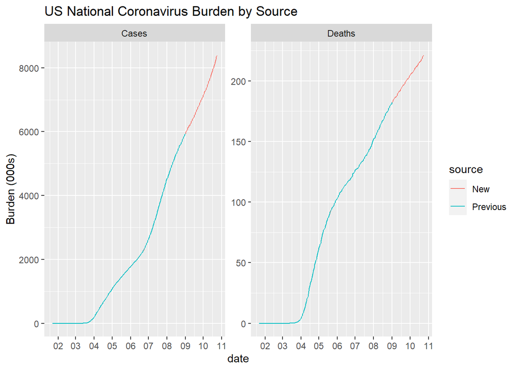

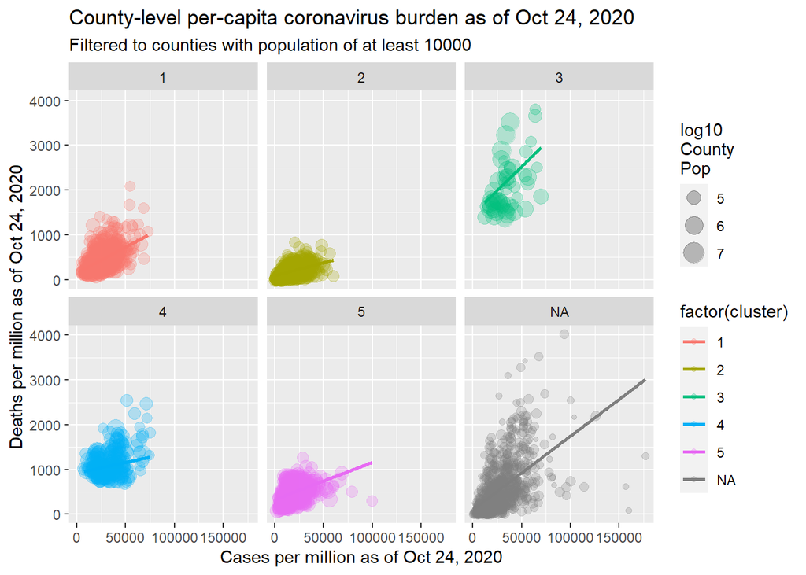

```
##
## Shapes will be created without any floor on the number of cases per million
## Shapes will be created without any floor on the number of deaths per million
## *** Counties with 0 cases/deaths or that fall below the floor for minCase/minDeath ***
## # A tibble: 1 x 4
##   cpm_mean_is0 dpm_mean_is0 dpm_mean_ltDeath cpm_mean_ltCase
##          <dbl>        <dbl>            <dbl>           <dbl>
## 1            0       0.0138                0               0
```

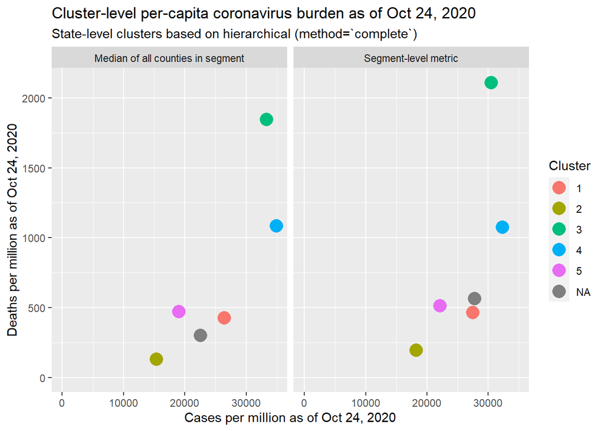

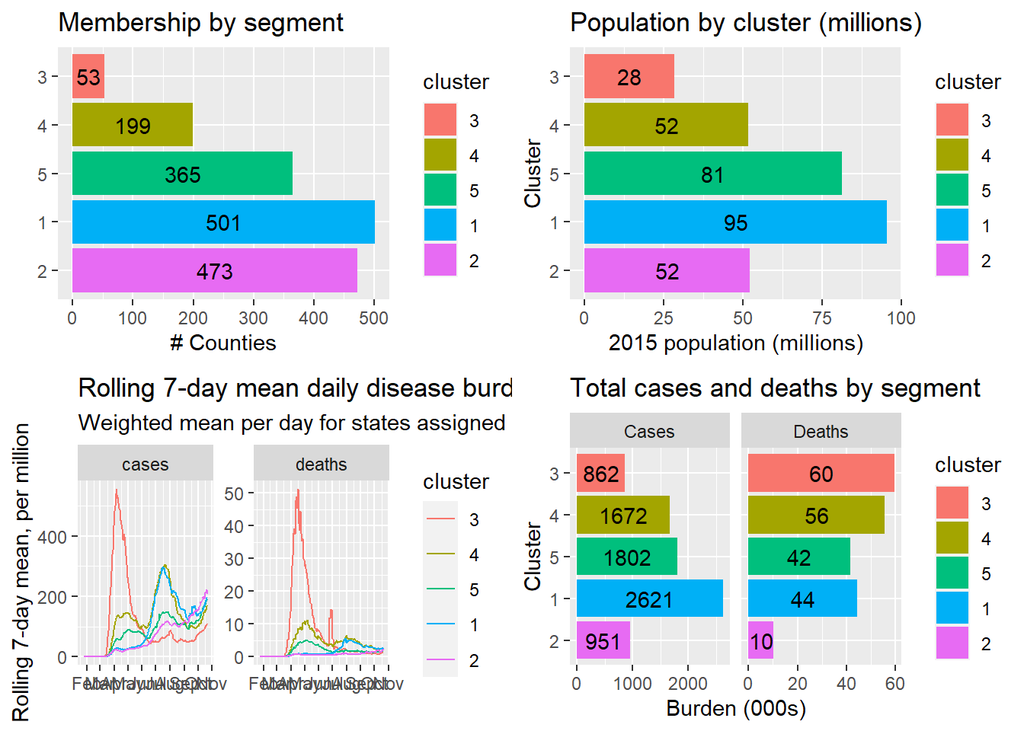

```
##
## Recency is defined as 2020-09-25 through current
##
## Recency is defined as 2020-09-25 through current
```

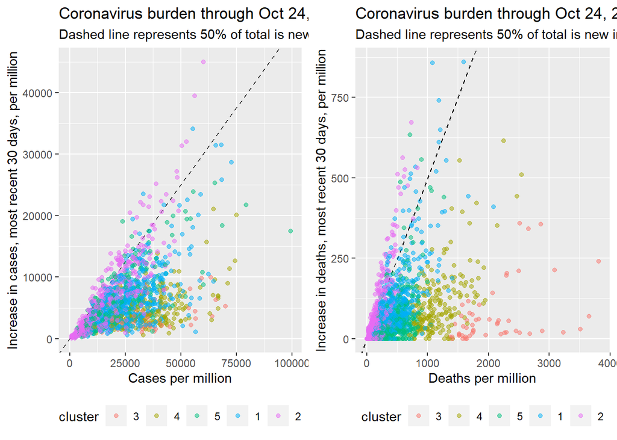

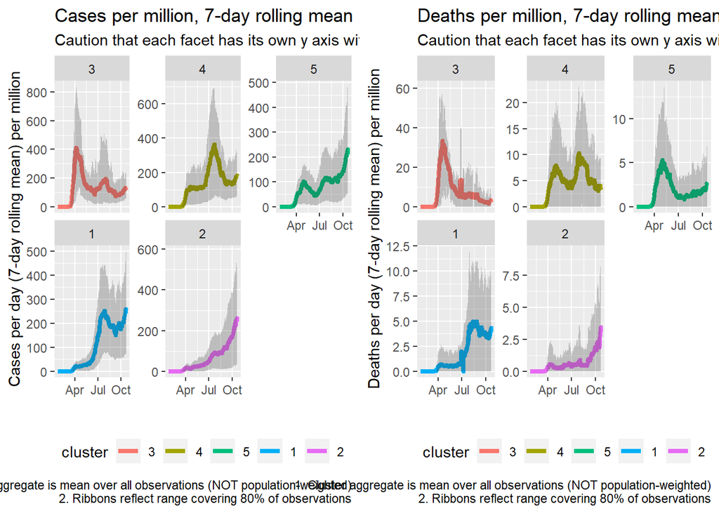

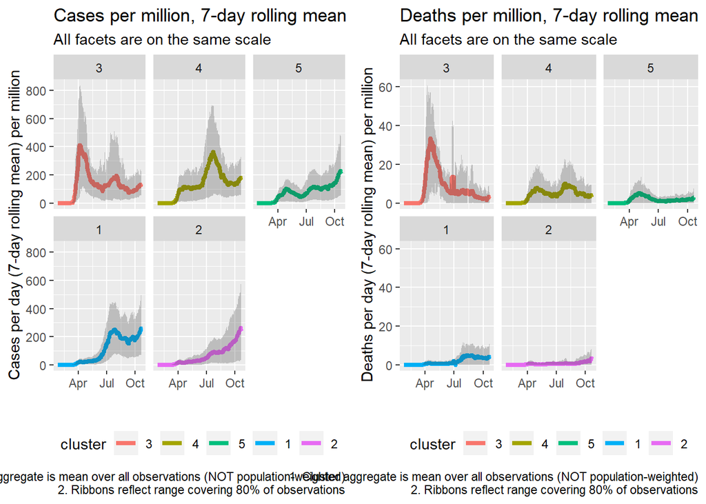

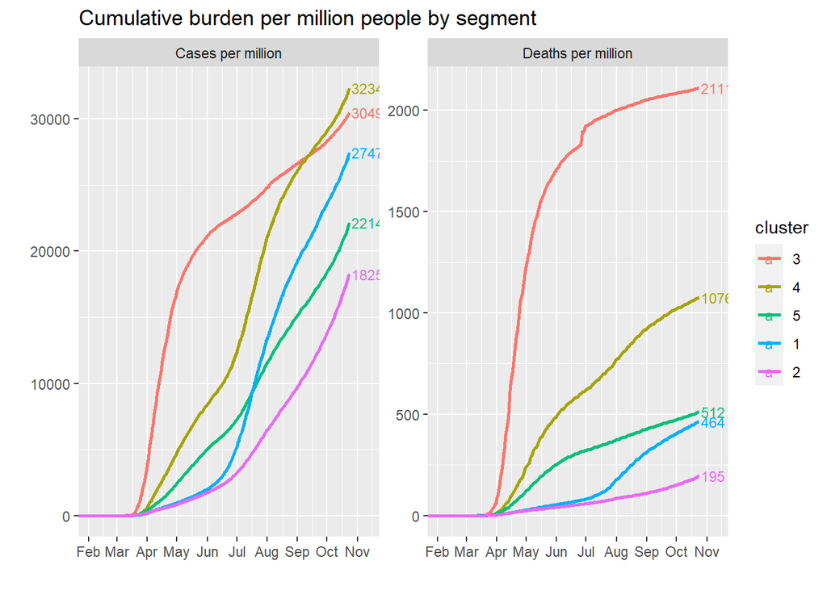

#### *Saving key files as RDS*

```r
saveToRDS(cty_20201026, ovrWriteError=FALSE)
saveToRDS(cty_old_20201026, ovrWriteError=FALSE)
```